# ENERGY

- **Author**: [Andy Wang](https://www.linkedin.com/in/andy-wang-3b595a299/), Johns Hopkins University, Class of 2027
- **Github Repository**: https://github.com/sirandy3000/projects/tree/master/energy

### Abstract

This R notebook contains my solution to the 2022 WiDS competition. The objective is to predict a building’s Site Energy Usage Intensity metric. To solve this problem, I first performed Exploratory Data Analysis, considering each feature’s distribution and correlation with Site EUI, to better understand the possible insights that each feature could provide. I then engineered and transformed features using techniques such as Iterative Imputation and Categorical Encoding. Finally, I performed cross-validation on several models and fine-tuned the hyperparameters of the best performer to make the best possible final Site EUI predictions.

### Contents

1. Project Setup
2. Exploratory Data Analysis
3. Data Preprocessing

## 1. Project Setup

In this section, I import required libraries and load the dataset.

### 1.1) Library Import

```r
library(dplyr)
library(ggplot2)
library(parsnip)
library(readr)
library(recipes)
library(stringr)
library(tidyr)
```

### 1.2) Data Load

I manually download the dataset from [Kaggle](https://www.kaggle.com/competitions/widsdatathon2022/data). The dataset arrives in two parts: a training set that contains the target variable, and the test set that does not.

```r
train <- read_csv("train.csv")
test  <- read_csv("test.csv")
```

## 2. Exploratory Data Analysis

In this section, I explore the dataset, including:

- The number of features and instances
- The distribution of each feature
- Correlation between each feature and the target

### 2.1) Dataset Information

The training dataset contains 75757 instances, 62 features (58 quantitative and 4 categorical), the target variable `site_eui`, and an ID column. The test dataset contains 9705 instances.

```r
glimpse(train)
```

```
## Rows: 75,757
## Columns: 64
## $ Year_Factor               <dbl> 1, 1, 1, 1, 1, 1, 1, 1, 1, 1, 1, 1, 1, 1, 1,…
## $ State_Factor              <chr> "State_1", "State_1", "State_1", "State_1", …
## $ building_class            <chr> "Commercial", "Commercial", "Commercial", "C…
## $ facility_type             <chr> "Grocery_store_or_food_market", "Warehouse_D…
## $ floor_area                <dbl> 61242, 274000, 280025, 55325, 66000, 119900,…
## $ year_built                <dbl> 1942, 1955, 1951, 1980, 1985, 1956, 1982, 19…
## $ energy_star_rating        <dbl> 11, 45, 97, 46, 100, NA, 56, 99, 98, 83, 51,…
## $ ELEVATION                 <dbl> 2.4, 1.8, 1.8, 1.8, 2.4, 2.4, 2.4, 2.4, 2.4,…
## $ january_min_temp          <dbl> 36, 36, 36, 36, 36, 36, 36, 36, 36, 36, 36, …
## $ january_avg_temp          <dbl> 50.5, 50.5, 50.5, 50.5, 50.5, 50.5, 50.5, 50…
## $ january_max_temp          <dbl> 68, 68, 68, 68, 68, 68, 68, 68, 68, 68, 68, …
## $ february_min_temp         <dbl> 35, 35, 35, 35, 35, 35, 35, 35, 35, 35, 35, …
## $ february_avg_temp         <dbl> 50.58929, 50.58929, 50.58929, 50.58929, 50.5…
```

[output cut: 51 more lines]

```r
nrow(test)
```

```
## [1] 9705
```

### 2.2) Feature Distributions

Visualization reveals that many quantitative features have highly abnormal distributions.

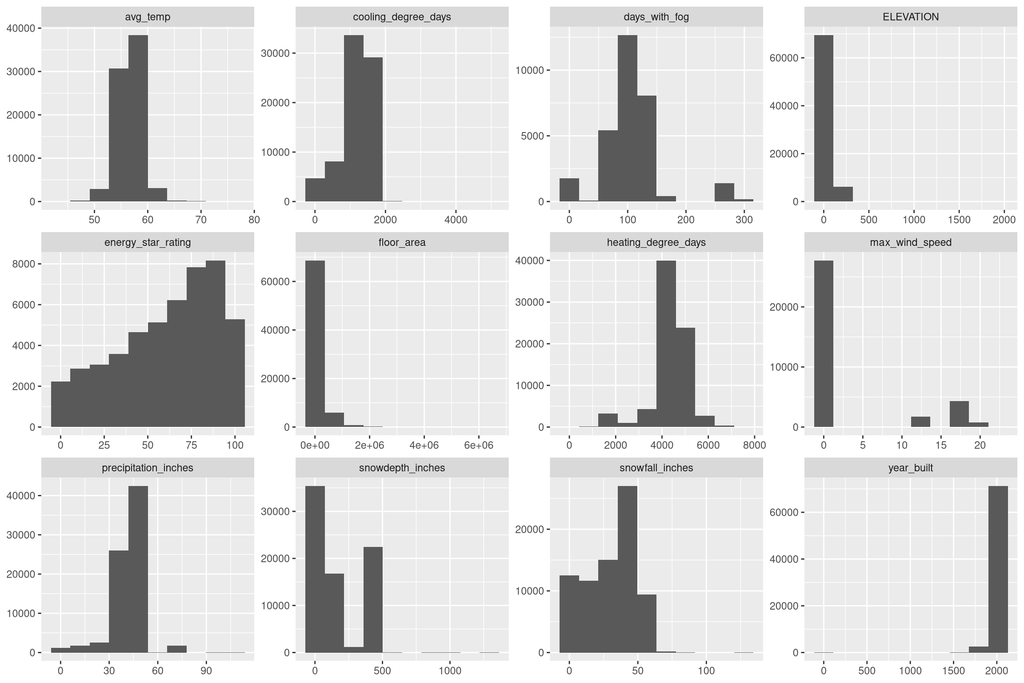

```r
quant_features <- train |>
  select(
    floor_area, year_built, energy_star_rating, ELEVATION,
    ends_with("degree_days"), ends_with("inches"),
    avg_temp, max_wind_speed, days_with_fog
  )

ggplot(gather(quant_features), aes(value)) +
  geom_histogram(bins = 10) +
  labs(x = NULL, y = NULL) +
  facet_wrap(~key, scales = "free")
```

Buildings in 7 undisclosed states were surveyed over the course of 6 undisclosed years. More residential buildings were surveyed than commerical buildings.

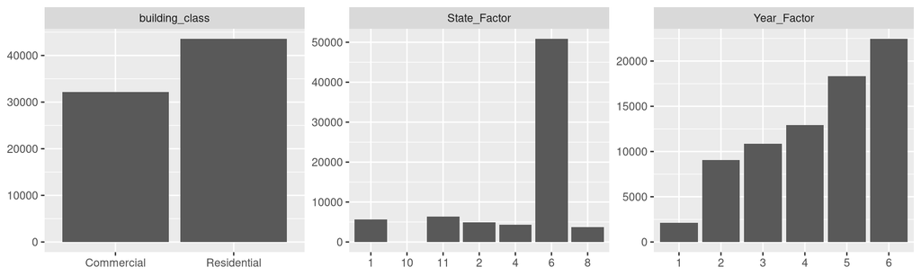

```r
cat_features <- train |>
  mutate(State_Factor = as.numeric(str_split_i(State_Factor, "_", -1))) |>
  select(Year_Factor, State_Factor, building_class)

ggplot(gather(cat_features), aes(value)) +
  geom_bar() +
  labs(x = NULL, y = NULL) +
  facet_wrap(~key, scales = "free")
```

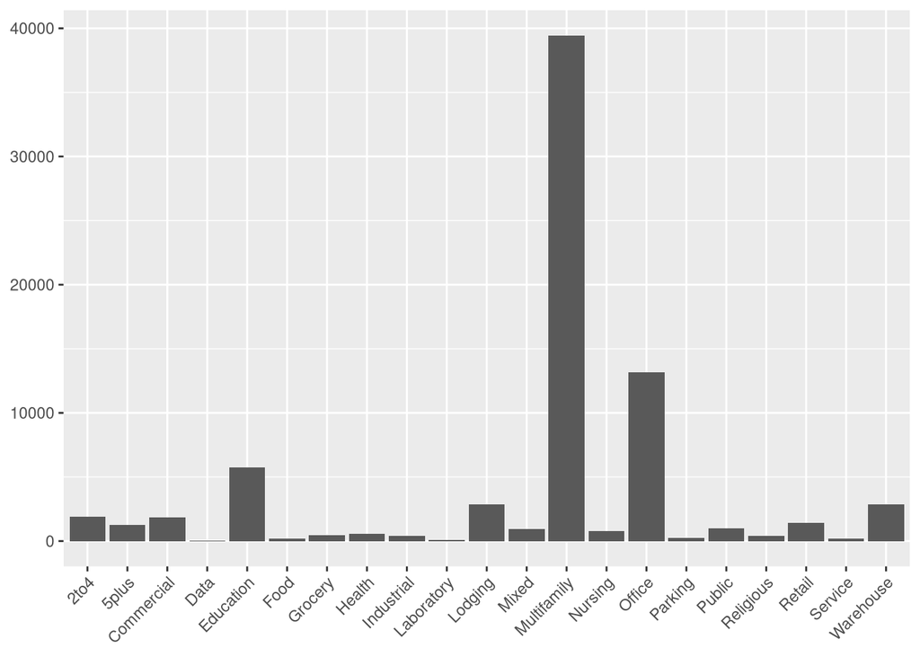

```r
facility <- train |>
  mutate(type = str_split_i(facility_type, "_", 1)) |>
  select(type)

ggplot(facility, aes(type)) +
  geom_bar() +
  labs(x = NULL, y = NULL) +
  theme(axis.text.x = element_text(angle = 45, hjust = 1))
```

### 2.3) Correlation

Before feature engineering, `energy_star_rating` is by far the feature most strongly correlated with `site_eui`. This makes sense, as buildings that use energy more intensely are likely to have lower Energy Star ratings.

```r
quant_features <- train |>
  drop_na() |>
  select(where(is.numeric) & !c(Year_Factor, id))

corr <- as_tibble(t(cor(quant_features)[, "site_eui"])) |>
  pivot_longer(everything(), names_to = "feature", values_to = "coefficient") |>
  filter(feature != "site_eui" & !is.na(coefficient)) |>
  arrange(desc(coefficient))

print(corr, n = Inf)
```

```
## # A tibble: 57 × 2
##    feature                   coefficient
##    <chr>                           <dbl>
##  1 july_avg_temp                0.130
##  2 june_avg_temp                0.124
##  3 snowfall_inches              0.110
##  4 precipitation_inches         0.102
##  5 cooling_degree_days          0.0971
##  6 july_min_temp                0.0954
##  7 snowdepth_inches             0.0887
##  8 heating_degree_days          0.0873
##  9 july_max_temp                0.0847
## 10 june_min_temp                0.0832
## 11 days_below_30F               0.0831
## 12 august_min_temp              0.0688
```

[output cut: 45 more lines]

## 3. Data Preprocessing

In this section, I preprocess the dataset, including:

- Removing duplicate entries
- Encoding categorical features
- Imputing missing values
- Engineering new features

### 3.1) Feature Names

I first standardized all feature names for convenience in further processing.

```r
preprocessing <- recipe(train, site_eui ~ .) |>
  step_rename_at(c(Year_Factor, State_Factor, ELEVATION), fn = tolower)
```

### 3.2) Duplicate Entries

A duplicate entry is defined in this context as any extra record for the same building. A duplicate entry will have the exact same values for all columns except ID. I removed duplicate entries in the training set: modifying the test set would mess up final predictions during submission.

```r
print(paste(
  sum(duplicated(select(train, !id))), "duplicate training instances,",
  sum(duplicated(select(test, !id))), "duplicate test instances."
))
```

```
## [1] "39 duplicate training instances, 5 duplicate test instances."
```

```r
preprocessing <- preprocessing |>
  step_filter(!duplicated(select(train, !id)))
```

### 3.3) Categorical Encoding

As the values of `state_factor` and `year_factor` are undisclosed, these features are unable to generate insights. Additionally, the values of `building_class` are reflected in the values of `facility_type`, making this feature redundant. The values of the remaining categorical feature, `facility_type`, have no innate ordering, so I used One-Hot Encoding to transform them into quantitative features.

```r
preprocessing <- preprocessing |>
  step_select(!c(year_factor, state_factor, building_class)) |>
  step_mutate(facility_type = str_split_i(facility_type, "_", 1)) |>
  step_string2factor(where(is.character)) |>
  step_dummy(all_factor_predictors())
```

### 3.4) Missing Values

6 features in the training set contain missing values. I removed features relating to fog or wind, which have the majority of their values missing: I imputed values in the remaining features, `energy_star_rating` and `year_built`, using a linear model.

```r
as_tibble(t(colSums(is.na(train)))) |>
  pivot_longer(everything(), names_to = "feature", values_to = "count") |>
  filter(count > 0) |>
  arrange(desc(count), feature) |>
  mutate(prop = count / nrow(train))
```

```
## # A tibble: 6 × 3
##   feature                   count   prop
##   <chr>                     <dbl>  <dbl>
## 1 days_with_fog             45796 0.605
## 2 direction_peak_wind_speed 41811 0.552
## 3 direction_max_wind_speed  41082 0.542
## 4 max_wind_speed            41082 0.542
## 5 energy_star_rating        26709 0.353
## 6 year_built                 1837 0.0242
```

```r
preprocessing <- preprocessing |>
  step_select(!ends_with("fog") & !ends_with("wind_speed")) |>
  step_impute_linear(
    energy_star_rating, year_built, impute_with = imp_vars(
      floor_area, elevation, avg_temp, ends_with("days"), ends_with("inches")
    )
  )
```

### 3.5) Feature Engineering / Selection

To reduce the number of features in the processed dataset, I combined the days_below_* and days_above_* features into cold_days and hot_days, respectively. I then combined average monthly temperatures to create average seasonal temperatures. I also engineered new features using the feature most correlated with `site_eui`, `energy_star_rating`. Finally, I selected the features to be used in the final dataset.

```r
preprocessing <- preprocessing |>
  step_mutate(
    cold_days         = days_below_30F + days_below_20F + days_below_10F + days_below_0F,
    hot_days          = days_above_80F + days_above_90F + days_above_100F + days_above_110F,
    spring_avg_temp   = march_avg_temp + april_avg_temp + may_avg_temp,
    summer_avg_temp   = june_avg_temp + july_avg_temp + august_avg_temp,
    autumn_avg_temp   = september_avg_temp + october_avg_temp + november_avg_temp,
    winter_avg_temp   = december_avg_temp + january_avg_temp + february_avg_temp,
    e_star_floor_area = energy_star_rating * floor_area,
    e_star_year_built = energy_star_rating * year_built,
    e_star_elevation  = energy_star_rating * elevation
  ) |>
  step_select(
    energy_star_rating, floor_area, year_built, elevation, precipitation_inches,
    snowfall_inches, cold_days, hot_days, starts_with("e_star"),
    matches("spring|summer|autumn|winter"), starts_with("facility"), site_eui
  )
```

```r
train_preprocessed <- preprocessing |> prep() |> bake(NULL)
glimpse(train_preprocessed)
```

```
## Rows: 75,718
## Columns: 36
## $ energy_star_rating        <dbl> 11.00000, 45.00000, 97.00000, 46.00000, 100.…
## $ floor_area                <dbl> 61242, 274000, 280025, 55325, 66000, 119900,…
## $ year_built                <dbl> 1942.000, 1955.000, 1951.000, 1980.000, 1985…
## $ elevation                 <dbl> 2.4, 1.8, 1.8, 1.8, 2.4, 2.4, 2.4, 2.4, 2.4,…
## $ precipitation_inches      <dbl> 16.59, 16.59, 16.59, 16.59, 16.59, 16.59, 16…
## $ snowfall_inches           <dbl> 0, 0, 0, 0, 0, 0, 0, 0, 0, 0, 0, 0, 0, 0, 0,…
## $ cold_days                 <dbl> 0, 0, 0, 0, 0, 0, 0, 0, 0, 0, 0, 0, 0, 0, 0,…
## $ hot_days                  <dbl> 14, 14, 14, 14, 14, 14, 14, 14, 14, 14, 14, …
## $ e_star_floor_area         <dbl> 673662, 12330000, 27162425, 2544950, 6600000…
## $ e_star_year_built         <dbl> 21362.0, 87975.0, 189247.0, 91080.0, 198500.…
## $ e_star_elevation          <dbl> 26.4000, 81.0000, 174.6000, 82.8000, 240.000…
## $ spring_avg_temp           <dbl> 166.0484, 166.0484, 166.0484, 166.0484, 166.…
## $ summer_avg_temp           <dbl> 185.3871, 185.3871, 185.3871, 185.3871, 185.…
```

[output cut: 23 more lines]